# Module 7 Guide

GEOG-3440

This document describes the important concepts, workflows, functions, and other information useful for this week.

### Readings

- Skim through this short article on useful [R Packages](https://support.posit.co/hc/en-us/articles/201057987-Quick-list-of-useful-R-packages)
- Read this article about on the Rise of [tidyverse](https://lrdegeest.github.io/blog/totalverse)
- Instead of using *reshape* functions outlined in the [R-Spatial book](https://rspatial.org/intr/11-dataprep.html), explore the [pivoting](https://cran.r-project.org/web/packages/tidyr/vignettes/pivot.html) functions in the `tidyr` package
- Read this article on What is [Spatial Data Science](http://gisgeography.com/spatial-data-science/)
- Read the **Introduction, Spatial data, and Vector data** sections under Spatial data with *terra* in the [R-Spatial book](https://rspatial.org/spatial/1-introduction.html)
- (optional) Use the [R for Data Science](https://r4ds.had.co.nz/introduction.html) book to learn more about tidyverse workflows in R

### Main Goals

1. Introduction to common packages in R
2. Efficient workflows with piping and dplyr
3. Visualization with ggplot
4. Pivot tables and advanced joins

## **1. Introduction to common packages in R**

One of the biggest benefits that open-source programming languages, like R, have is an extensive collection of custom packages developed by community members like you, and widely used throughout the globe! Although you likely already have a little exposure to different R packages, let’s discuss this a bit more formally.

In R, a **package** is a collection of pre-written functions, data sets, and documentation that extend the capabilities of R. Think of it as a toolkit that someone else has created to make specific tasks easier. For example, one package might help you visualize data, another might help you manipulate it, and yet another might provide tools for advanced statistical analysis. Instead of writing complex code from scratch, you can load a package and use its functions to accomplish tasks more efficiently. Packages can help you perform anything from basic calculations to building complex machine learning models, all while saving you time and effort.

The **tidyverse** is a collection of R packages that are designed to work together and provide a streamlined workflow for data science. It includes some popular and powerful packages, like `ggplot2` for visualization, `dplyr` for data manipulation, and `tidyr` for reshaping data. These packages share a common design philosophy, making it easier to learn and use them together. The tidyverse emphasizes readability and simplicity, so even non-programmers can quickly pick up these tools to clean, analyze, and visualize data. By using the tidyverse, you can follow a consistent workflow where tasks like cleaning data, exploring relationships, and presenting results become intuitive and less error-prone.

Installing a new package is easy, and you can do so in a couple of ways. The first method is using the **Packages** tab in RStudio. In the tab, you’ll find an “Install” button that allows you to search for and install packages directly from CRAN (the Comprehensive R Archive Network), which is the main repository for R packages. Alternatively, you can install packages manually using the function `install.packages()` (e.g., `install.packages("dplyr")`) in the console, and R will download and install it for you. Once the package is installed, you need to load it into your session with `library()` before you can start using it.

## **2. Efficient workflows with piping and dplyr**

The `dplyr` package simplifies data manipulation by providing functions that are intuitive and easy to use. We’ll go over some of the most commonly used functions: `select()`, `filter()`, `summarize()`, and piping (`%>%`).

First, similar to any package, you will need to load the `dplyr` libraries. Loading a packages brings the necessary functions into for your current R session, you will need to do this every time you start a new session. If you don’t have `dplyr` installed, you can install it by running `install.packages("dplyr")`.

```r
# Load the dplyr package
# install.packages("dplyr") # only need to install once!
library(dplyr)
```

The `%>%` operator, known as the “pipe”, allows you to chain functions together in a clean and readable way. This operator passes the output of one function as the input to the next function (as the first argument). That means that sometimes you will only have an empty function in your chain.

```r
# create dataframe and show the first twp rows
cbind("col1"=c("a","b","c", "d"), "col2"=1:4) %>%
  as.data.frame() %>% head(2)
```

```
##   col1 col2
## 1    a    1
## 2    b    2
```

We’ll use piping to chain together multiple steps below. The shortcut to add a pipe is *ctrl + shift + M*. It can also keep your code need to start new lines after a pipe.

The `select()` function is used to select specific columns from a data frame. This is similar to indexing by column (e.g., `df[, "col1"]`). Let’s use the built-in `mtcars` dataset for this example.

```r
# Select only the 'mpg' (miles per gallon) and 'hp' (horsepower) columns from mtcars
selected_data <- mtcars %>%
  select(mpg, hp)

# View the selected data
head(selected_data)
```

```
##                    mpg  hp
## Mazda RX4         21.0 110
## Mazda RX4 Wag     21.0 110
## Datsun 710        22.8  93
## Hornet 4 Drive    21.4 110
## Hornet Sportabout 18.7 175
## Valiant           18.1 105
```

The `filter()` function allows you to subset rows based on conditions. Here, we will filter the `mtcars` dataset to only include cars with more than 150 horsepower. This is similar to indexing by row to subset your data (e.g., `df[ df$col2 > 10 ,]`).

```r
# Filter rows where horsepower is greater than 150
mtcars %>%
  filter(hp > 150) %>%
  head()
```

```
##                     mpg cyl  disp  hp drat   wt  qsec vs am gear carb
## Hornet Sportabout  18.7   8 360.0 175 3.15 3.44 17.02  0  0    3    2
## Duster 360         14.3   8 360.0 245 3.21 3.57 15.84  0  0    3    4
## Merc 450SE         16.4   8 275.8 180 3.07 4.07 17.40  0  0    3    3
## Merc 450SL         17.3   8 275.8 180 3.07 3.73 17.60  0  0    3    3
## Merc 450SLC        15.2   8 275.8 180 3.07 3.78 18.00  0  0    3    3
## Cadillac Fleetwood 10.4   8 472.0 205 2.93 5.25 17.98  0  0    3    4
```

```r
# NOTE: this time we did not save the variable
```

The `summarize()` (or `summarise()`) function is used to aggregate data, such as calculating the mean or sum of a variable. We will compute the average miles per gallon (mpg) by the number of cylinders (using the `group_by()` function).

```r
# Summarize the average mpg by the number of cylinders
summary_data <- mtcars %>%
  group_by(cyl) %>%
  summarize(avg_mpg = mean(mpg))

# View the summary data
summary_data
```

```
## # A tibble: 3 × 2
##     cyl avg_mpg
##   <dbl>   <dbl>
## 1     4    26.7
## 2     6    19.7
## 3     8    15.1
```

The `mutate()` function is the last `dplyr` function we will discuss. This function allows you to add new columns, or update existing columns, in your dataset within a piping framework:

```r
# create new column for kilometers per liter from mpg
mtcars %>%
  mutate(km_l = round(mpg / 2.352, 1) ) %>% # conversion factor
  select(mpg, km_l) %>% head(4)
```

```
##                 mpg km_l
## Mazda RX4      21.0  8.9
## Mazda RX4 Wag  21.0  8.9
## Datsun 710     22.8  9.7
## Hornet 4 Drive 21.4  9.1
```

Note, these functions also work outside of piping, but are typically most effective when used in a chain.

*Several other functions exist in the dplyr package that will be useful! Continue to explore other possibilities.*

## **3. Visualization with ggplot**

`ggplot2` is a powerful package for creating visualizations in R. It uses a grammar of graphics, which allows you to build plots layer by layer.

Just like with `dplyr`, you’ll need to install and load `ggplot2`. You can install it with `install.packages("ggplot2")`.

```r
# Load the ggplot2 package
library(ggplot2)
```

Let’s start with a simple scatter plot using the `mtcars` dataset. We’ll plot `mpg` (miles per gallon) on the y-axis and `hp` (horsepower) on the x-axis. `ggplot` uses the `aes()` or aesthetic function to map values of x and y. Aesthetic mapping is a key part of this package. Another great thing with ggplot is that the functions recognize column names as standalone variables:

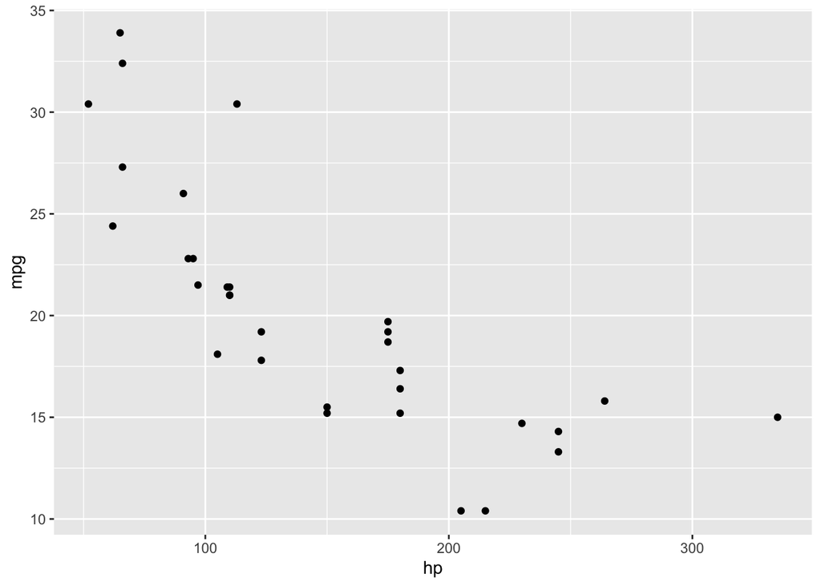

```r
# Scatter plot of mpg vs. hp
ggplot(mtcars, aes(x = hp, y = mpg)) +
  geom_point()
```

**Note**, `ggplot` has it’s own way of chaining together plot functions. This is similar to the pipe `%>%` but keep in mind that one is for `ggplot` and other for `dplyr`.

You can enhance your plots by adding titles, axis labels, and customizing the appearance.

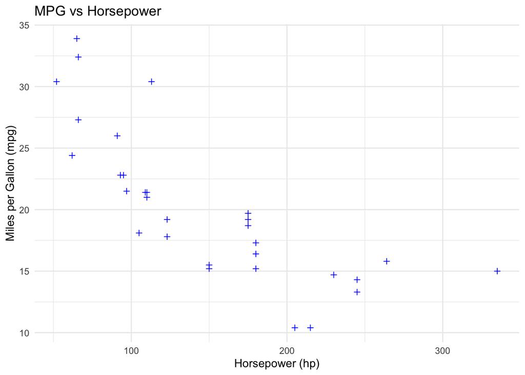

```r
# plot with titles and customized appearance
mtcars %>% # dplyr chaining
  ggplot(aes(x = hp, y = mpg)) + # ggplot chaining
  geom_point(color = "blue", shape = 3) +
  labs(title = "MPG vs Horsepower",
       x = "Horsepower (hp)",
       y = "Miles per Gallon (mpg)") +
  theme_minimal()
```

To visualize data by groups, you can color the points by another variable. Let’s color the points based on the number of cylinders (`cyl`).

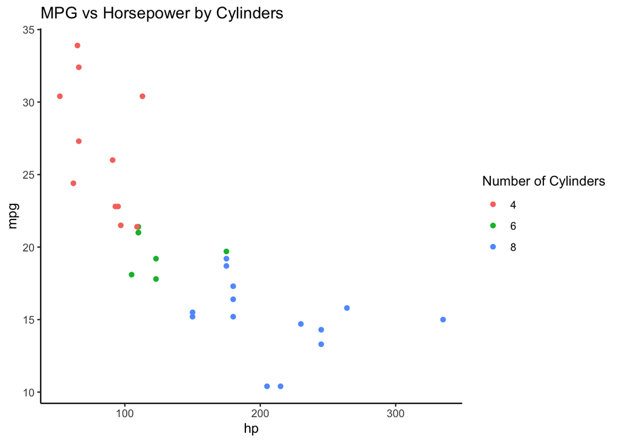

```r
# Scatter plot with points colored by 'cyl'
ggplot(mtcars, aes(x = hp, y = mpg, color = factor(cyl))) +
  geom_point() +
  labs(title = "MPG vs Horsepower by Cylinders",
       color = "Number of Cylinders") +
  theme_classic()
```

A boxplot is another type of plot you can create with `ggplot2` to visualize the distribution of a variable. Let’s create a boxplot of `mpg` by the number of cylinders.

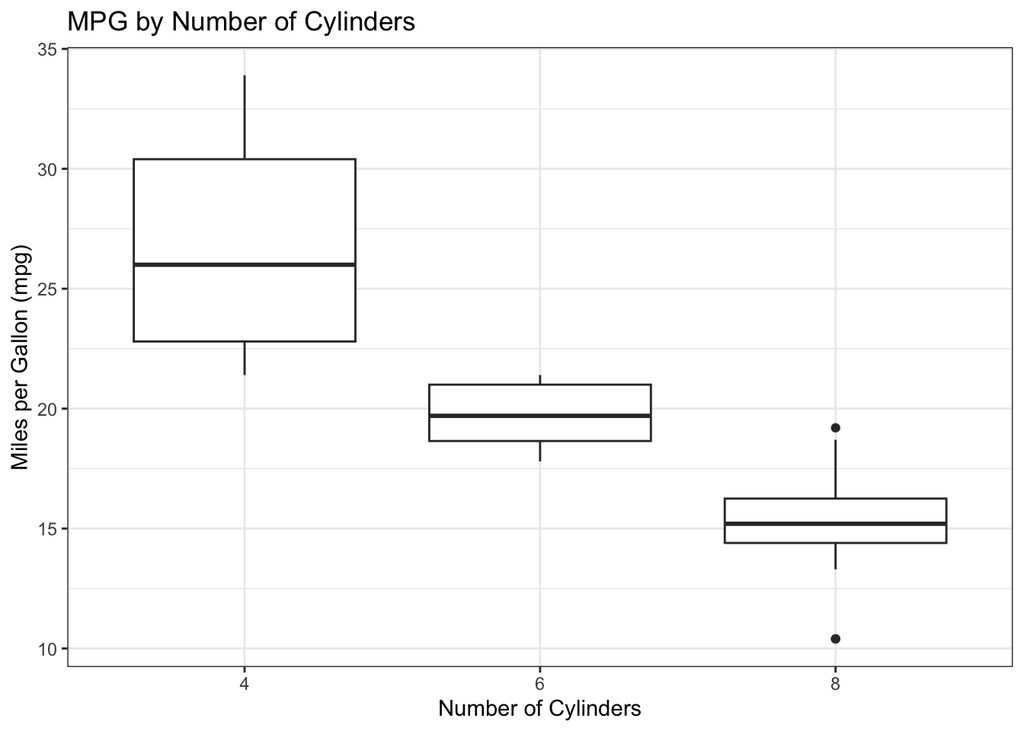

```r
# Boxplot of mpg by cyl
ggplot(mtcars, aes(x = factor(cyl), y = mpg)) +
  geom_boxplot() +
  labs(title = "MPG by Number of Cylinders",
       x = "Number of Cylinders",
       y = "Miles per Gallon (mpg)") +
  theme_bw()
```

You can save your plot using the export function in R or with the `ggsave()` function.

```r
# Save the last plot as a PNG file
ggsave("mpg_vs_hp_plot.png")
```

This section shows you that there is more than one way to metaphorically *skin a cat*. You see how `dplyr` can be used for data manipulation and `ggplot2` for creating better visualizations. These two packages are are widely used for exploring and understanding data in R. Once you’re comfortable with the basics, you can start exploring more advanced techniques and additional packages that make R an even more powerful tool for data science!

There are many other R packages that can complement the packages described above. Here are a few popular ones you can explore:

- **`tidyr`**: A package for reshaping data, helping with tidying up datasets (e.g., `gather()`, `spread()` functions), *which we will discuss in the next sections*.
- **`lubridate`**: Helps with working with dates and times in R.
- **`readr`**: A package for fast reading of CSV and other data formats.
- **`plotly`**: For interactive plots and visualizations.

As stated above, **you can choose to work primarily in base R** but I would **strongly encourage you to become familiar with other packages** in R to improve your data science capabilities!

## **4. Pivot tables and advanced joins**

You previously read in the R Spatial book about preparing data by reshaping and merging, however, there are a better ways to perform these tasks using other R packages.

#### **Pivoting**

Pivoting is used to restructure data—converting columns into rows (wide to long format) or vice versa (long to wide format). The `reshape()` function in base R is versatile and can help achieve this transformation. Let’s look at an example where we have environmental data on temperatures measured across different months.

```r
# xreate a sample data frame of average temperatures for each month
temp_data <- data.frame(
  Location = c("Location1", "Location2"),
  Jan = c(30, 25),
  Feb = c(32, 28),
  Mar = c(40, 35)
)

print(temp_data)
```

```
##    Location Jan Feb Mar
## 1 Location1  30  32  40
## 2 Location2  25  28  35
```

```r
# reshape from wide to long format
long_temp_data <- reshape(temp_data,
                          varying = c("Jan", "Feb", "Mar"),
                          v.names = "Temperature",
                          timevar = "Month",
                          times = c("Jan", "Feb", "Mar"),
                          direction = "long")
print(long_temp_data)
```

```
##        Location Month Temperature id
## 1.Jan Location1   Jan          30  1
## 2.Jan Location2   Jan          25  2
## 1.Feb Location1   Feb          32  1
## 2.Feb Location2   Feb          28  2
## 1.Mar Location1   Mar          40  1
## 2.Mar Location2   Mar          35  2
```

This will convert the data frame from a wide format to a long format, where each row represents a month’s temperature for each location. While this *base R* function is useful, there are libraries that contain better pivoting functions.

To reshape and merge data in a better way, you can use the `tidyr` alongside the `dplyr` library in R. Specifically, we’ll explore the `pivot_longer()` and `pivot_wider()` functions from `tidyr` to reshape the data.

```r
# Load libraries
# library(dplyr) # load if needed
# install.packages("tidyr") # if not already installed
library(tidyr)
```

Let’s create some example data frames to use for pivoting and merging. `dplyr` and `tidyr` can work with dataframes but typically prefers a `tibble()`. Both **tibbles** and **data frames** are used to store tabular data, but tibbles are a modern version of data frames from the **tidyverse** that address some of their limitations. Tibbles are more user-friendly for displaying large datasets, and allow for more intuitive column access.

```r
# Wide format data
data_wide <- tibble(
  id = 1:3,
  name = c("John", "Alice", "Bob"),
  score_math = c(95, 88, 92),
  score_english = c(85, 90, 89)
)
# View data
print(data_wide)
```

```
## # A tibble: 3 × 4
##      id name  score_math score_english
##   <int> <chr>      <dbl>         <dbl>
## 1     1 John          95            85
## 2     2 Alice         88            90
## 3     3 Bob           92            89
```

In data science, **long format** refers to a structure where each observation is represented by a single row, and multiple measurements or variables are stored in separate columns, often with one column specifying the variable type (e.g., “score” or “subject”). **Wide format**, on the other hand, arranges data such that each unique variable gets its own column, with each row typically representing an individual observation. Long format is often preferred for analysis and modeling because it is more flexible and compatible with many statistical functions and tools, while wide format is easier to read and interpret for smaller datasets or when comparing a few variables. The `pivot_longer()` function reshapes the data from wide to long format. It collapses multiple columns into two columns: one for the variable name (e.g., `score_math`) and one for the values (e.g., `95`).

```r
# Pivot the wide data to long format
data_long <- data_wide %>%
  pivot_longer(cols = starts_with("score"),
               names_to = "subject",
               values_to = "score")

# View the long data
print(data_long)
```

```
## # A tibble: 6 × 4
##      id name  subject       score
##   <int> <chr> <chr>         <dbl>
## 1     1 John  score_math       95
## 2     1 John  score_english    85
## 3     2 Alice score_math       88
## 4     2 Alice score_english    90
## 5     3 Bob   score_math       92
## 6     3 Bob   score_english    89
```

The `pivot_wider()` function reshapes the data back from long to wide format, spreading the values of a column into multiple columns based on a key.

```r
# Pivot the long data back to wide format
data_wide_again <- data_long %>%
  pivot_wider(names_from = "subject", values_from = "score")

# View the wide data
print(data_wide_again)
```

```
## # A tibble: 3 × 4
##      id name  score_math score_english
##   <int> <chr>      <dbl>         <dbl>
## 1     1 John          95            85
## 2     2 Alice         88            90
## 3     3 Bob           92            89
```

*Another popular library for data manipulation, which we will not cover is the* `reshape2` *package, which has the* `melt` *function.*

#### **Merging and joins**

Joining datasets relies on key on similar key variables between data. You’ve already explored some ways in base R to match values between datasets:

Recall the `match` function returns the location of the match of x, which can be numeric or character:

```r
match(5, 1:9) # 5
match(5, c(1,2,3,6,7,8,9,5)) # 8
match("B", c("A","B","C")) # 2
```

You can also use the `%in%` (wrapper for match) to return a logical expression to check if a value exists at all in the vector:

```r
capletters <-  c("B","Z","F","D","A","G","C")
"A" %in% capletters # TRUE
"J" %in% capletters # FALSE
5 %in% 1:9 # TRUE
```

These methods are useful, but what about for more complicated tasks? You previously worked with the `merge` function in base R, which combines datasets using matched key columns. The *dplyr* package contains a several ways to join data that can be more intuitive. Let’s read in a secondary dataset with additional information.

```r
# secondary dataset
data_info <- tibble(
  id = c(1, 2, 3, 4),
  age = c(20, 25, 22, 26),
  grade = c("A", "B", "A", "C")
)

# View data
print(data_info)
```

```
## # A tibble: 4 × 3
##      id   age grade
##   <dbl> <dbl> <chr>
## 1     1    20 A
## 2     2    25 B
## 3     3    22 A
## 4     4    26 C
```

Now, let’s merge the `data_wide` and `data_info` datasets using the `left_join()` and `full_join()` functions from `dplyr`.

The `left_join()` function combines two datasets by matching rows based on a common column. It keeps all rows from the left dataset (`data_wide`) and adds matching rows from the right dataset (`data_info`).

```r
# Left join data_wide with data_info based on 'id'
data_left_joined <- data_wide %>%
  left_join(data_info, by = "id")

# View the result of the left join
print(data_left_joined)
```

```
## # A tibble: 3 × 6
##      id name  score_math score_english   age grade
##   <dbl> <chr>      <dbl>         <dbl> <dbl> <chr>
## 1     1 John          95            85    20 A
## 2     2 Alice         88            90    25 B
## 3     3 Bob           92            89    22 A
```

The `full_join()` function returns all rows from both datasets, filling in missing values with `NA` where necessary.

```r
# Full join data_wide with data_info based on 'id'
data_full_joined <- data_wide %>%
  full_join(data_info, by = "id")

# View the result of the full join
print(data_full_joined)
```

```
## # A tibble: 4 × 6
##      id name  score_math score_english   age grade
##   <dbl> <chr>      <dbl>         <dbl> <dbl> <chr>
## 1     1 John          95            85    20 A
## 2     2 Alice         88            90    25 B
## 3     3 Bob           92            89    22 A
## 4     4 <NA>          NA            NA    26 C
```

Note that merge and join functions operate on matching (see `match` function) variables between datasets. While some data can be combined with `cbind` and `rbind`, a true merge requies a specialized function that ensures fidelity in the matching of the two datasets.

**Recap of Functions Used:**

- `pivot_longer()`: Converts wide format data to long format by collapsing multiple columns into two (key-value pairs).
- `pivot_wider()`: Converts long format data back into wide format by spreading key-value pairs into columns.
- `left_join()`: Merges two datasets based on a common column, keeping all rows from the left dataset.
- `full_join()`: Merges two datasets based on a common column, keeping all rows from both datasets.

Data manipulation is a key part of data science. Your workflows will improve as you discover new libraries and functions throughout the semester.

There are tens of thousands of R packages developed by the community and many new, useful packages are developed each year! The R community is vast and an excellent place to learn and grow your geospatial data science skills.

**Complete the Module Task** by updating the provided *Template* The task submission this week is different than previous weeks